# Lab 3

Xuan Wen Loo

2023-03-24

Link to github repo: https://github.com/xuanwenloo/Homework7

```r
library(tidyverse)
```

```r
library(dplyr)
library(ggplot2)
```

```r
data(happy, package="productplots")
head(happy)
```

```
##   id         happy year age    sex       marital         degree       finrela
## 1  1 not too happy 1972  23 female never married       bachelor       average
## 2  2 not too happy 1972  70   male       married lt high school above average
## 3  3  pretty happy 1972  48 female       married    high school       average
## 4  4 not too happy 1972  27 female       married       bachelor       average
## 5  5  pretty happy 1972  61 female       married    high school above average
## 6  6  pretty happy 1972  26   male never married    high school above average
##      health wtssall
## 1      good  0.4446
## 2      fair  0.8893
## 3 excellent  0.8893
## 4      good  0.8893
## 5      good  0.8893
## 6      good  0.4446
```

```r
HAPPY <- readRDS("data/HAPPY.rds")
```

**Part one (cleaning)**

1. Data cleaning: the values “IAP”, “DK” and “NA” all encode missing values. Replace all of these instances by the value NA.

```r
HAPPY[HAPPY == "IAP" | HAPPY == "DK"| HAPPY == 'NA'] = NA
head(HAPPY)
```

```
##           HAPPY YEAR AGE    SEX       MARITAL         DEGREE       FINRELA
## 1 NOT TOO HAPPY 1972  23 FEMALE NEVER MARRIED       BACHELOR       AVERAGE
## 2 NOT TOO HAPPY 1972  70   MALE       MARRIED LT HIGH SCHOOL ABOVE AVERAGE
## 3  PRETTY HAPPY 1972  48 FEMALE       MARRIED    HIGH SCHOOL       AVERAGE
## 4 NOT TOO HAPPY 1972  27 FEMALE       MARRIED       BACHELOR       AVERAGE
## 5  PRETTY HAPPY 1972  61 FEMALE       MARRIED    HIGH SCHOOL ABOVE AVERAGE
## 6  PRETTY HAPPY 1972  26   MALE NEVER MARRIED    HIGH SCHOOL ABOVE AVERAGE
##      HEALTH WTSSALL          PARTYID POLVIEWS
## 1      GOOD  0.4446     IND,NEAR DEM     <NA>
## 2      FAIR  0.8893 NOT STR DEMOCRAT     <NA>
## 3 EXCELLENT  0.8893      INDEPENDENT     <NA>
## 4      GOOD  0.8893 NOT STR DEMOCRAT     <NA>
## 5      GOOD  0.8893  STRONG DEMOCRAT     <NA>
## 6      GOOD  0.4446     IND,NEAR DEM     <NA>
```

2. Check the type of the variable and cast into the right type (factor variable for categorical variables). For age, change “89 OR OLDER” to 89 and assume the variable should be numeric.

```r
str(HAPPY)
```

```
## 'data.frame':    62466 obs. of  11 variables:
##  $ HAPPY   : chr  "NOT TOO HAPPY" "NOT TOO HAPPY" "PRETTY HAPPY" "NOT TOO HAPPY" ...
##  $ YEAR    : int  1972 1972 1972 1972 1972 1972 1972 1972 1972 1972 ...
##  $ AGE     : chr  "23" "70" "48" "27" ...
##  $ SEX     : chr  "FEMALE" "MALE" "FEMALE" "FEMALE" ...
##  $ MARITAL : chr  "NEVER MARRIED" "MARRIED" "MARRIED" "MARRIED" ...
##  $ DEGREE  : chr  "BACHELOR" "LT HIGH SCHOOL" "HIGH SCHOOL" "BACHELOR" ...
##  $ FINRELA : chr  "AVERAGE" "ABOVE AVERAGE" "AVERAGE" "AVERAGE" ...
##  $ HEALTH  : chr  "GOOD" "FAIR" "EXCELLENT" "GOOD" ...
##  $ WTSSALL : num  0.445 0.889 0.889 0.889 0.889 ...
##  $ PARTYID : chr  "IND,NEAR DEM" "NOT STR DEMOCRAT" "INDEPENDENT" "NOT STR DEMOCRAT" ...
##  $ POLVIEWS: chr  NA NA NA NA ...
```

```r
HAPPY$AGE[HAPPY$AGE == '89 OR OLDER'] = 89
HAPPY$AGE = as.numeric(HAPPY$AGE)
str(HAPPY)
```

```
## 'data.frame':    62466 obs. of  11 variables:
##  $ HAPPY   : chr  "NOT TOO HAPPY" "NOT TOO HAPPY" "PRETTY HAPPY" "NOT TOO HAPPY" ...
##  $ YEAR    : int  1972 1972 1972 1972 1972 1972 1972 1972 1972 1972 ...
##  $ AGE     : num  23 70 48 27 61 26 28 27 21 30 ...
##  $ SEX     : chr  "FEMALE" "MALE" "FEMALE" "FEMALE" ...
##  $ MARITAL : chr  "NEVER MARRIED" "MARRIED" "MARRIED" "MARRIED" ...
##  $ DEGREE  : chr  "BACHELOR" "LT HIGH SCHOOL" "HIGH SCHOOL" "BACHELOR" ...
##  $ FINRELA : chr  "AVERAGE" "ABOVE AVERAGE" "AVERAGE" "AVERAGE" ...
##  $ HEALTH  : chr  "GOOD" "FAIR" "EXCELLENT" "GOOD" ...
##  $ WTSSALL : num  0.445 0.889 0.889 0.889 0.889 ...
##  $ PARTYID : chr  "IND,NEAR DEM" "NOT STR DEMOCRAT" "INDEPENDENT" "NOT STR DEMOCRAT" ...
##  $ POLVIEWS: chr  NA NA NA NA ...
```

3. Bring all levels of factors into a sensible order. For marital you could e.g. order the levels according to average age.

```r
col = c('HAPPY', 'SEX', 'MARITAL', 'DEGREE', 'FINRELA', 'HEALTH', 'PARTYID', 'POLVIEWS')
HAPPY[col] = lapply(HAPPY[col], factor)
levels(HAPPY$MARITAL)
```

```
## [1] "DIVORCED"      "MARRIED"       "NEVER MARRIED" "SEPARATED"
## [5] "WIDOWED"
```

```r
levels(HAPPY$DEGREE)
```

```
## [1] "BACHELOR"       "GRADUATE"       "HIGH SCHOOL"    "JUNIOR COLLEGE"
## [5] "LT HIGH SCHOOL"
```

```r
levels(HAPPY$FINRELA)
```

```
## [1] "ABOVE AVERAGE"     "AVERAGE"           "BELOW AVERAGE"
## [4] "FAR ABOVE AVERAGE" "FAR BELOW AVERAGE"
```

```r
levels(HAPPY$HEALTH)
```

```
## [1] "EXCELLENT" "FAIR"      "GOOD"      "POOR"
```

```r
levels(HAPPY$PARTYID)
```

```
## [1] "IND,NEAR DEM"       "IND,NEAR REP"       "INDEPENDENT"
## [4] "NOT STR DEMOCRAT"   "NOT STR REPUBLICAN" "OTHER PARTY"
## [7] "STRONG DEMOCRAT"    "STRONG REPUBLICAN"
```

```r
levels(HAPPY$POLVIEWS)
```

```
## [1] "CONSERVATIVE"         "EXTREMELY LIBERAL"    "EXTRMLY CONSERVATIVE"
## [4] "LIBERAL"              "MODERATE"             "SLGHTLY CONSERVATIVE"
## [7] "SLIGHTLY LIBERAL"
```

```r
h = HAPPY
h$MARITAL = factor(h$MARITAL, levels = c('NEVER MARRIED', 'MARRIED', 'SEPARATED', 'DIVORCED', 'WIDOWED'))

h$DEGREE = factor(h$DEGREE, levels = c('LT HIGH SCHOOL', 'HIGH SCHOOL', 'JUNIOR COLLEGE', 'BACHELOR', 'GRADUATE'))

h$FINRELA = factor(h$FINRELA, levels = c('FAR BELOW AVERAGE', 'BELOW AVERAGE', 'AVERAGE', 'ABOVE AVERAGE', 'FAR ABOVE AVERAGE'))

h$HEALTH = factor(h$HEALTH, levels = c('POOR', 'FAIR', 'GOOD', 'EXCELLENT'))

h$PARTYID = factor(h$PARTYID, levels = c('STRONG DEMOCRAT', 'NOT STR DEMOCRAT', 'IND,NEAR DEMOCRAT', 'INDEPENDENT', 'IND,NEAR REP', 'NOT STR REPUBLICAN', 'STRONG REPUBLICAN', 'OTHER PARTY'))

h$POLVIEWS = factor(h$POLVIEWS, levels = c('EXTREMELY LIBERAL', 'LIBERAL', 'SLIGHTLY LIBERAL', 'MODERATE', 'SLIGHTLY CONSERVATIVE', 'CONSERVATIVE', 'EXTREMLY CONSERVATIVE'))

HAPPY = h
str(HAPPY)
```

```
## 'data.frame':    62466 obs. of  11 variables:
##  $ HAPPY   : Factor w/ 3 levels "NOT TOO HAPPY",..: 1 1 2 1 2 2 1 1 2 2 ...
##  $ YEAR    : int  1972 1972 1972 1972 1972 1972 1972 1972 1972 1972 ...
##  $ AGE     : num  23 70 48 27 61 26 28 27 21 30 ...
##  $ SEX     : Factor w/ 2 levels "FEMALE","MALE": 1 2 1 1 1 2 2 2 1 1 ...
##  $ MARITAL : Factor w/ 5 levels "NEVER MARRIED",..: 1 2 2 2 2 1 4 1 1 2 ...
##  $ DEGREE  : Factor w/ 5 levels "LT HIGH SCHOOL",..: 4 1 2 4 2 2 2 4 2 2 ...
##  $ FINRELA : Factor w/ 5 levels "FAR BELOW AVERAGE",..: 3 4 3 3 4 4 4 3 3 2 ...
##  $ HEALTH  : Factor w/ 4 levels "POOR","FAIR",..: 3 2 4 3 3 3 4 3 4 2 ...
##  $ WTSSALL : num  0.445 0.889 0.889 0.889 0.889 ...
##  $ PARTYID : Factor w/ 8 levels "STRONG DEMOCRAT",..: NA 2 4 2 1 NA NA NA 1 1 ...
##  $ POLVIEWS: Factor w/ 7 levels "EXTREMELY LIBERAL",..: NA NA NA NA NA NA NA NA NA NA ...
```

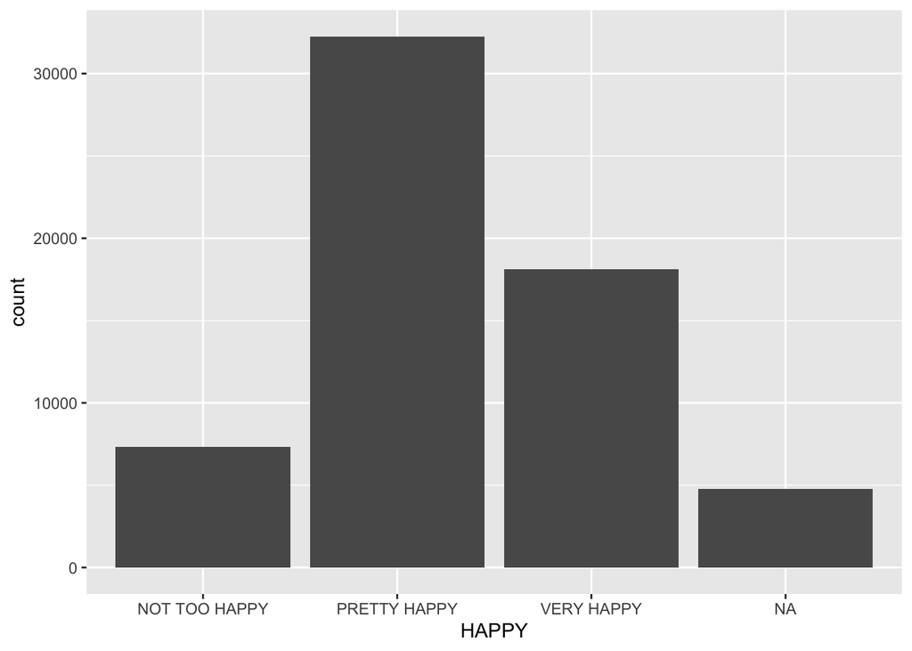

```r
ggplot(HAPPY, aes(x = HAPPY)) + geom_bar()
```

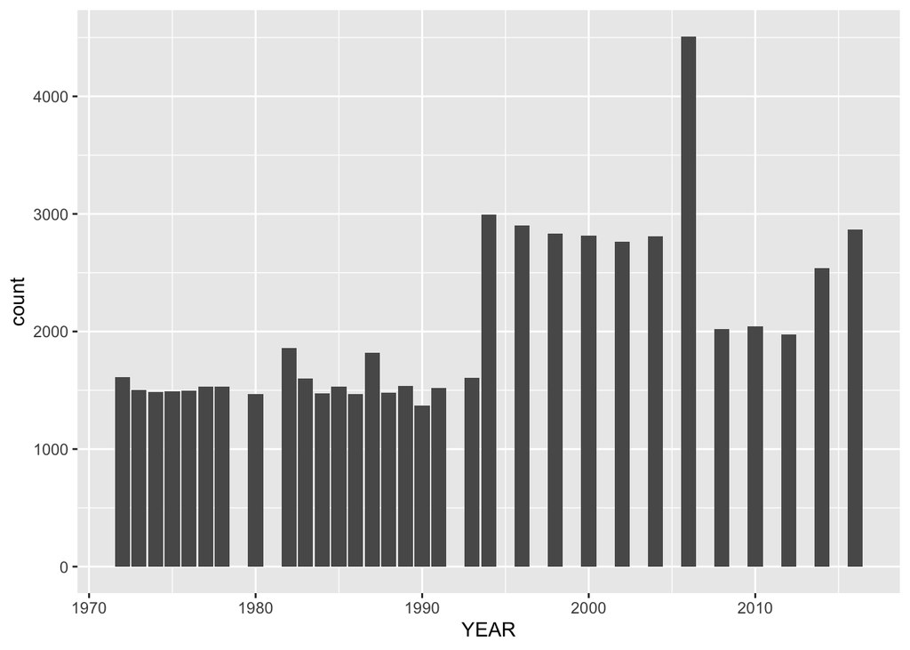

```r
ggplot(HAPPY, aes(x = YEAR)) + geom_bar()
```

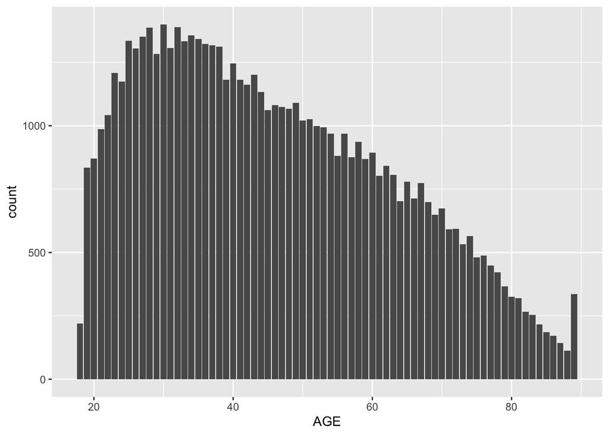

```r
ggplot(HAPPY, aes(x = AGE)) + geom_bar()
```

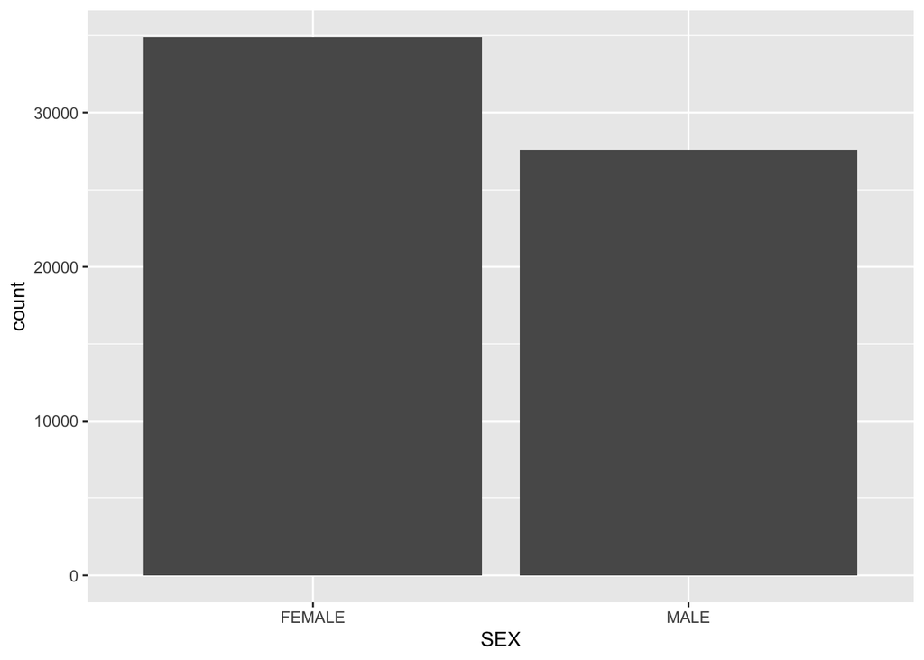

```r
ggplot(HAPPY, aes(x = SEX)) + geom_bar()
```

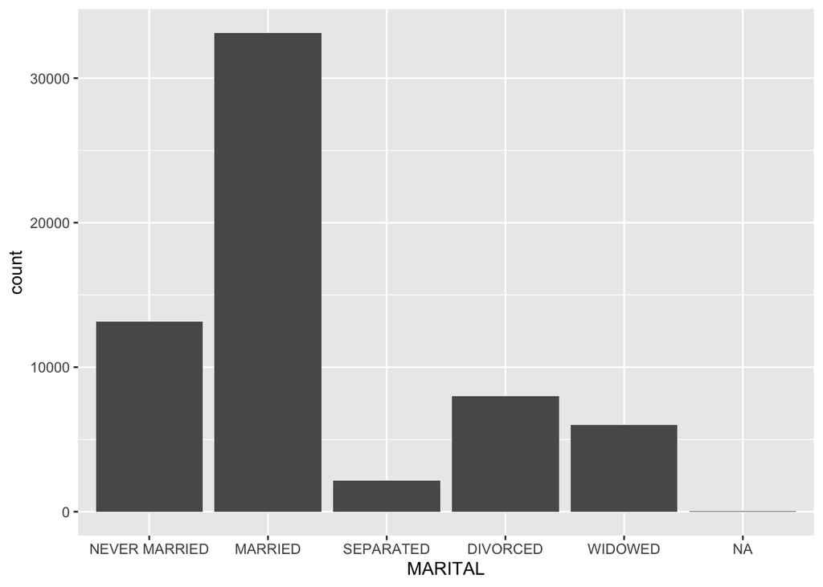

```r
ggplot(HAPPY, aes(x = MARITAL)) + geom_bar()
```

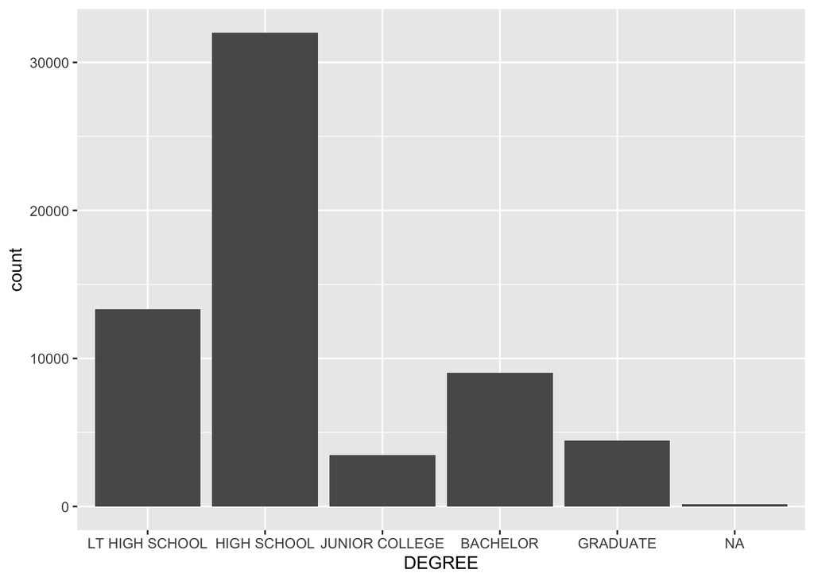

```r
ggplot(HAPPY, aes(x = DEGREE)) + geom_bar()
```

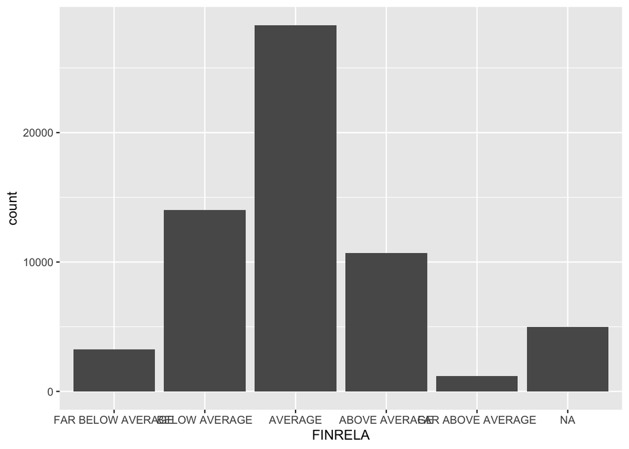

```r
ggplot(HAPPY, aes(x = FINRELA)) + geom_bar()
```

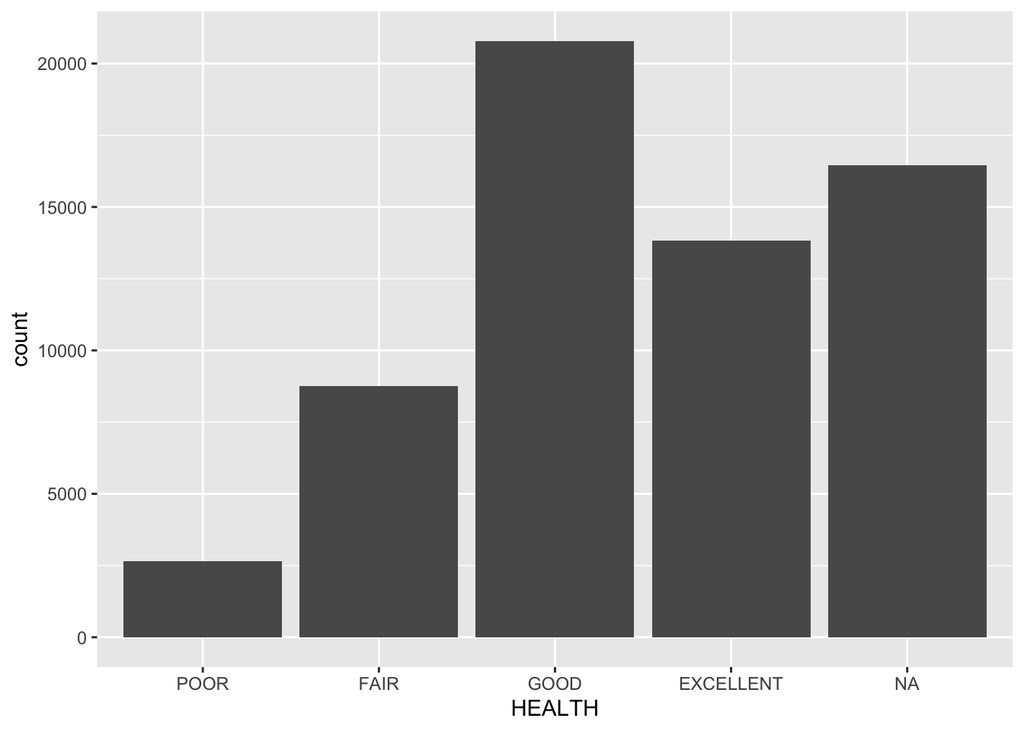

```r
ggplot(HAPPY, aes(x = HEALTH)) + geom_bar()
```

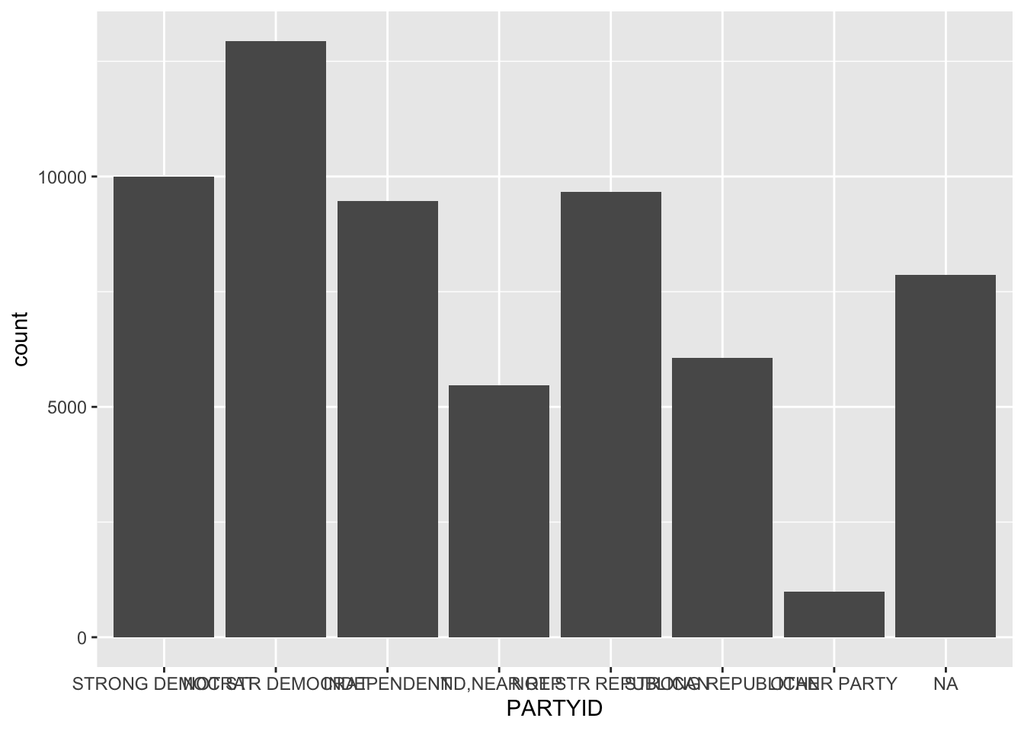

```r
ggplot(HAPPY, aes(x = PARTYID)) + geom_bar()
```

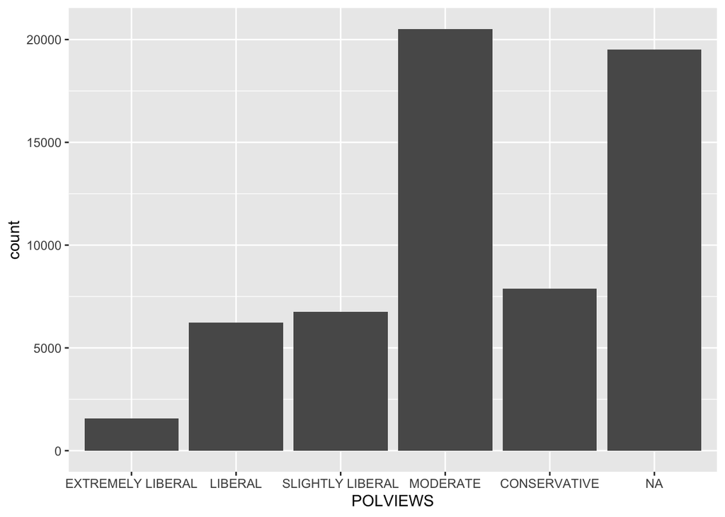

```r
ggplot(HAPPY, aes(x = POLVIEWS)) + geom_bar()
```

**Part two (individual exploration)**

I will be investigating the relationship between happiness and degree and marital status.

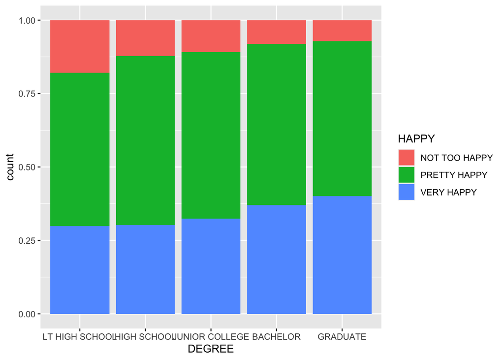

```r
ggplot(na.omit(HAPPY), aes(x = DEGREE, fill = HAPPY)) + geom_bar(position = "fill")
```

The plot shows that people with higher academic qualifications are happier, most probably because they have higher achievements in the society, and they can get a better job with a good pay.

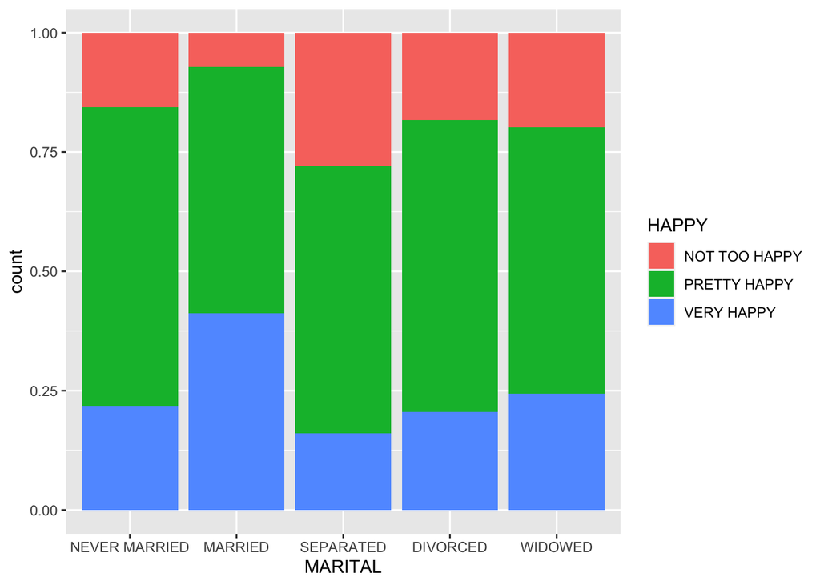

```r
ggplot(na.omit(HAPPY), aes(x = MARITAL, fill = HAPPY)) + geom_bar(position = "fill")
```

The plot shows that the proportion of very happy people is the largest in married couples, and least among separated couples. This is most probably because married people have a harmonious family which will make them happier.

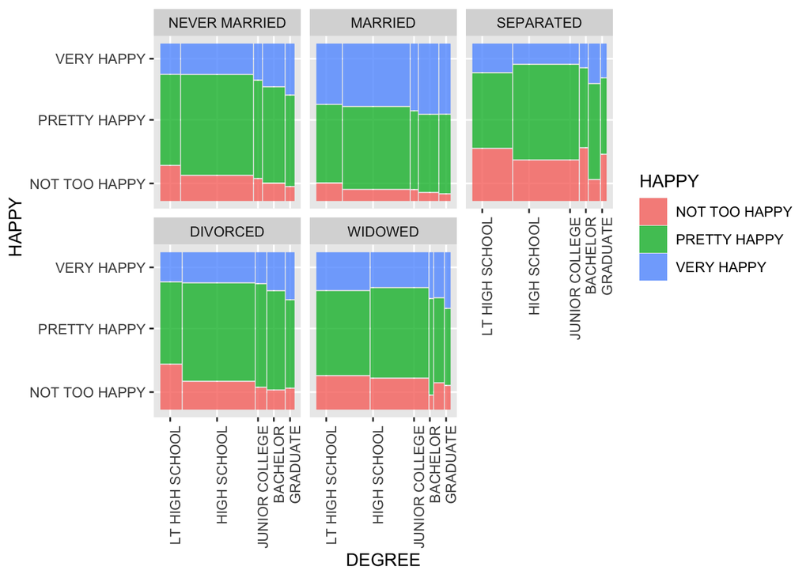

```r
library(ggmosaic)
ggplot(na.omit(HAPPY)) + geom_mosaic(aes(x = product(DEGREE), fill = HAPPY)) + facet_wrap(~MARITAL) +
  theme(axis.text.x = element_text(angle = 90, hjust = 1))
```

From the plot, it seemed that married people with high academic achievements are most likely to be happier compared to people who failed a relationship and did not have high degrees.